# Paxgene RIN Issue

Christopher Jin

2023-01-10

# Preparing variables for analysis

We created new columns for flagged_sample (based on pain, swelling, bruising, etc during collection), calculated freeze time, ethnicity, age group bins, and BMI for PCA analysis. These are variables that might relate to variation in gene expression.

# MOP-flagged samples

The RNA-seq pipeline manual of procedures (MOP) defines a flagged sample (e.g., potentially problematic) as a sample that satisfies one of the following: (1) number of read pairs $<20M$, (2) percent GC not in $[20,80]$, (3) percent rRNA reads $>20$, (4) percent of uniquely mapped reads $<60$, (5) RIN $<6$, and (6) percent coding reads + percent utr reads $< 50$.

# Dataset normalization through TMM

We first remove unexpressed genes using the min_cpm and min_num_samples parameters. We then use edgeR for library size correction and for TMM normalization. For each dataset (i.e., tissue) we store the normalized data table and all additional variables (e.g., clinical data) in a list called norm_rnaseq_data.

```r
min_cpm = 0.5
min_num_samples_pct = 0.1
norm_method="TMM"
# Specify how many PCs to examine
num_pcs = 5
num_pcs_for_outlier_analysis = 3
# Specify the significance level for association analysis
# (e.g., between a PC and a clinical variable)
p_thr = 0.0001
norm_rnaseq_data = list()
for (tissue in c('muscle_data','blood_data')) {
  unnorm_counts = rna_seq_data[[tissue]] #ref standards are in here
  curr_samples = as.character(colnames(unnorm_counts))
  norm_counts = edgeR_normalized_log_cpm(as.matrix(unnorm_counts),
                                         min_cpm = min_cpm,
                                         min_num_samples = round(length(unnorm_counts)*min_num_samples_pct),
                                         norm_method = norm_method
  )
  curr_meta1 = rna_seq_data$rnaseq_meta[curr_samples,]
  curr_meta2 = rna_seq_data$pheno_data[curr_samples,]
  curr_meta <- cbind(curr_meta1,curr_meta2)
  norm_rnaseq_data[[tissue]] = list(
    norm_counts = norm_counts,
    raw_counts = unnorm_counts[rownames(unnorm_counts) %in% rownames(norm_counts),],
    metadata = curr_meta)
}
```

# Batch correction

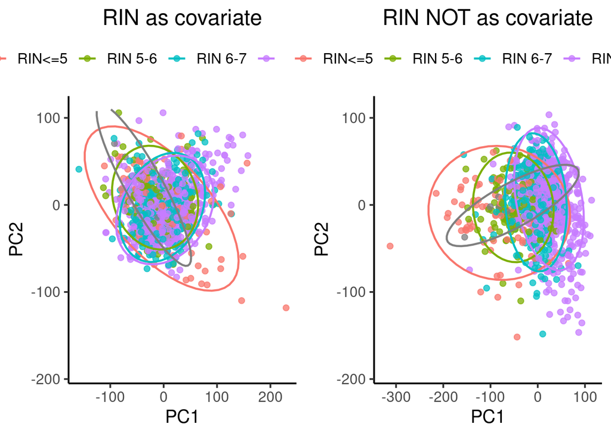

```r
var = 'RINcut'
blood_pcas = cbind(norm_rnaseq_data[['blood_data']]$pca_w_rin,norm_rnaseq_data[['blood_data']]$metadata)
blood_pcas$PID<-NULL

blood_pcas$RINcut <- cut(blood_pcas$RIN,c(0,5,6,7,20),labels=c('RIN<=5','RIN 5-6','RIN 6-7','RIN>7'))
g1 = ggplot(data=blood_pcas,aes_string(x='PC1',y='PC2',color=var))+
  geom_point(size=2,alpha=0.75)+
  stat_ellipse(size=0.8,type = 't')+
  ylim(c(-190,110))+
  guides(color=guide_legend(nrow=1,byrow=TRUE))+
  theme_classic(base_size = 15)+labs(title='RIN as covariate',x="PC1",y="PC2")+
  theme(legend.position="top",legend.title=element_blank(),plot.title = element_text(hjust = 0.5))
blood_pcas = cbind(norm_rnaseq_data[['blood_data']]$pca_no_rin,norm_rnaseq_data[['blood_data']]$metadata)
blood_pcas$PID<-NULL
blood_pcas$RINcut <- cut(blood_pcas$RIN,c(0,5,6,7,20),labels=c('RIN<=5','RIN 5-6','RIN 6-7','RIN>7'))
g2 = ggplot(data=blood_pcas,aes_string(x='PC1',y='PC2',color=var))+
  geom_point(size=2,alpha=0.75)+
  stat_ellipse(size=0.8,type = 't')+
  ylim(c(-190,110))+
  guides(color=guide_legend(nrow=1,byrow=TRUE))+
  theme_classic(base_size = 15)+labs(title='RIN NOT as covariate',x="PC1",y="PC2")+
  theme(legend.position="top",legend.title=element_blank(),plot.title = element_text(hjust = 0.5))
grid.arrange(g1, g2, ncol = 2)
```

```r
library(RColorBrewer)
library(viridis)
```

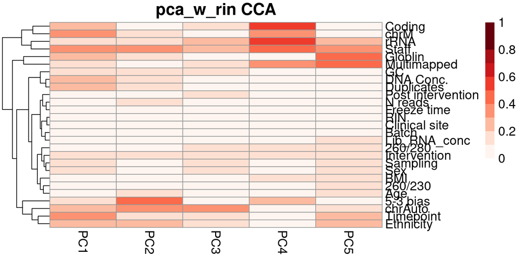

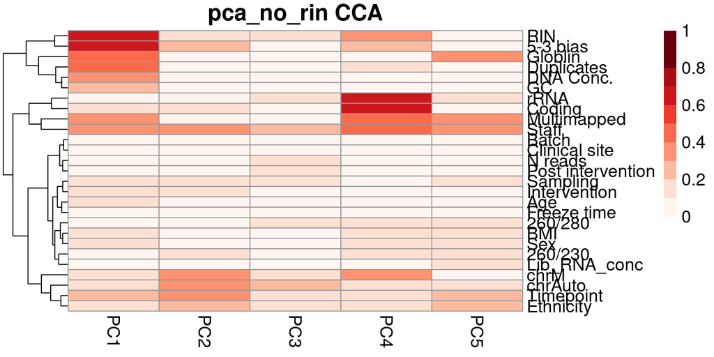

```r
library(pheatmap)
pca_conds = c('pca_w_rin', 'pca_no_rin')
for (cond in pca_conds){
  blood_pcas = cbind(norm_rnaseq_data[['blood_data']][[cond]],norm_rnaseq_data[['blood_data']]$metadata)
  form <- ~ PC1 + PC2 + PC3 + PC4 + PC5 + RIN + Lib_DNA_conc + reads + r_260_280 + r_260_230 + pct_rRNA + pct_globin + pct_coding + pct_chrAuto + pct_umi_dup + median_5_3_bias + Batch + pct_multimapped + pct_GC + pct_chrM + clinical_site + age + temporal_sampling_profile + pre_or_post_visit + randomGroupCode + timepointDescription + Ethnicity + BMI + Sex + coll_staffid + blood_freezetime + Lib_RNA_conc
  # Blood:
  # Compute Canonical Correlation Analysis (CCA) between all pairs of variables
  # returns absolute correlation value
  C_blood = canCorPairs(form, blood_pcas)
  rownames(C_blood) <- c("PC1","PC2","PC3","PC4","PC5","RIN","DNA Conc.", "N reads", "260/280", "260/230","rRNA","Globlin","Coding","chrAuto",'Duplicates',
                         '5-3 bias', 'Batch','Multimapped','GC','chrM','Clinical site','Age','Sampling','Post intervention', 'Intervention', 'Timepoint',
                         'Ethnicity','BMI','Sex','Staff','Freeze time', 'Lib_RNA_conc')

  colnames(C_blood) <- c("PC1","PC2","PC3","PC4","PC5","RIN","DNA Conc.", "N reads", "260/280", "260/230","rRNA","Globlin","Coding","chrAuto",'Duplicates',
                         '5-3 bias', 'Batch','Multimapped','GC','chrM','Clinical site','Age','Sampling','Post intervention', 'Intervention', 'Timepoint',
                         'Ethnicity','BMI','Sex','Staff','Freeze time', 'Lib_RNA_conc')
  # Plot correlation matrix
  coul <- brewer.pal(9, "Reds")
  pcs <- c("PC1","PC2","PC3","PC4","PC5")
  breaksList = seq(0, 1.00, by = 0.1)
  pheatmap(C_blood[!rownames(C_blood) %in% pcs,pcs],color=coul,breaks=breaksList,fontsize = 14, cluster_cols = F,main = paste(cond,"CCA"))
}
```

## Differential analysis between refs - Split by gender

```r
blood_only = norm_rnaseq_data$blood_data
refs_blood = rownames(blood_only$metadata[blood_only$metadata$is_ref == 'True',])
# filt counts
counts = blood_only[['raw_counts']]  #remember that the counts matrix is cols not rows

# remove outliers
meta = blood_only[['metadata']]
meta$RIN = ifelse(is.na(meta$RIN), mean(meta$RIN, na.rm = T), meta$RIN)
median_bloods_refs_rin = median(na.omit(blood_only[['metadata']][refs_blood,]$RIN))
meta$group = ifelse(meta$SampleTypeCode=='f-paxgene rna'& meta$RIN < median_bloods_refs_rin, "f_lowrins", "") #set the first test occurance to empty
meta$group = ifelse(meta$SampleTypeCode=='f-paxgene rna'& meta$RIN > median_bloods_refs_rin, "f_highrins", meta$group)

meta$group = ifelse(meta$SampleTypeCode=='m-paxgene rna'& meta$RIN < median_bloods_refs_rin, "m_lowrins", meta$group)
meta$group = ifelse(meta$SampleTypeCode=='m-paxgene rna'& meta$RIN > median_bloods_refs_rin, "m_highrins", meta$group)

#Number of samples in ea group: f-lowrins: 4, f-highrins: 2, m_lowrins = 5, m_highrins = 8

curr_meta = as.data.frame(meta) #1,062 entries, 328 total columns

message("Performing differential analysis for ...")
```

```
## Performing differential analysis for ...
```

```r
full = paste0(c("~ 0", "Sex", "Batch", "group"), collapse=" + ")
full_w_rin = paste0(c("~ 0", "Sex", "Batch", "group", "RIN"), collapse=" + ")
#So we can't include age_groups as a covariate if we're including the ref stnds, unless we want to assign a random age group for the ref stnds.

# normalize and get voom weights
design = stats::model.matrix(eval(parse(text=full)), data = curr_meta)
design_w_rin = stats::model.matrix(eval(parse(text=full_w_rin)), data = curr_meta)

counts <- counts[,colnames(counts) %in% rownames(design)] #trim samples that aren't in the meta sheet (this is bc of missing RIN....)


voom_res = limma::voom(counts, normalize.method = "quantile", design = design)

fit = limma::lmFit(voom_res, design)
fit_w_rin = limma::lmFit(voom_res, design_w_rin)

#contrasts based on the
cont.matrix = limma::makeContrasts(
  'male' = "groupm_lowrins - groupm_highrins",
  'female' = "groupf_lowrins - groupf_highrins",
  levels = design)
cont_with_rin.matrix = limma::makeContrasts(
  'male' = "groupm_lowrins - groupm_highrins",
  'female' = "groupf_lowrins - groupf_highrins",
  levels = design_w_rin)

fit2 = limma::contrasts.fit(fit,cont.matrix)
fit2_w_rin = limma::contrasts.fit(fit_w_rin,cont_with_rin.matrix)
e = limma::eBayes(fit2)
e_w_rin = limma::eBayes(fit2_w_rin)
```

# DA Figure for the male ref standards, split for visualization purposes.

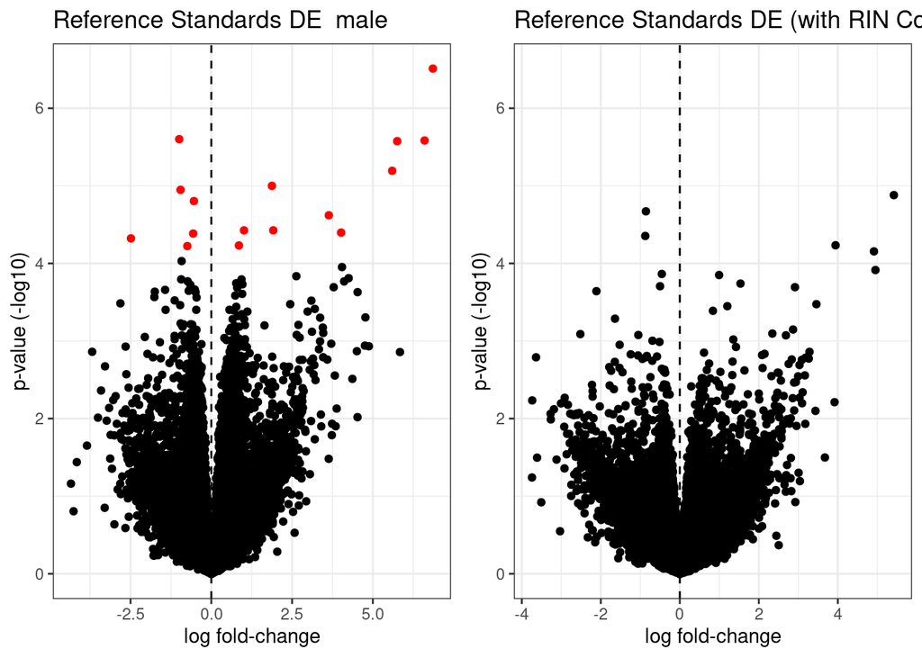

```r
da_list_m = list()
#adjusted p_value at 0.1 bc frankly 0.05 gave <10 for each gender...
res = limma::topTable(e, number=nrow(e), coef='male', confint=TRUE)
res_w_rin = limma::topTable(e_w_rin, number=nrow(e_w_rin), coef='male', confint=TRUE)

dt = data.table::data.table(
  feature_ID = rownames(res),
  logFC = res$logFC,
  logFC_se = (res$CI.R - res$CI.L)/3.92,
  tscore = res$t,
  p_value = res$P.Value
)
dt[,adj_p_value := p.adjust(p_value, method="BH")]
dt[,colour := ifelse(adj_p_value < 0.1, "red", "black")]

dt_w_rin = data.table::data.table(
  feature_ID = rownames(res_w_rin),
  logFC = res_w_rin$logFC,
  logFC_se = (res_w_rin$CI.R - res_w_rin$CI.L)/3.92,
  tscore = res_w_rin$t,
  p_value = res_w_rin$P.Value
)
dt_w_rin[,adj_p_value := p.adjust(p_value, method="BH")]
dt_w_rin[,colour := ifelse(adj_p_value < 0.1, "red", "black")]

# volcano plot
g = ggplot(dt, aes(y=-log10(p_value), x=logFC, colour=colour)) +
  geom_point() +
  scale_colour_identity() +
  geom_vline(xintercept = 0, linetype="dashed", colour="black") +
  theme_bw() +
  labs(x="log fold-change", y="p-value (-log10)", title=paste("Reference Standards DE ", 'male')) +
  ylim(0, max(-log10(dt$p_value)))

g_w_rin = ggplot(dt_w_rin, aes(y=-log10(p_value), x=logFC, colour=colour)) +
  geom_point() +
  scale_colour_identity() +
  geom_vline(xintercept = 0, linetype="dashed", colour="black") +
  theme_bw() +
  labs(x="log fold-change", y="p-value (-log10)", title=paste("Reference Standards DE (with RIN Covariate)", 'male')) +
  ylim(0, max(-log10(dt$p_value)))
grid.arrange(g, g_w_rin, ncol = 2)
```

```r
message(nrow(dt[adj_p_value < 0.1 & logFC > 0]))
```

```
## 10
```

```r
message(nrow(dt[adj_p_value < 0.1 & logFC < 0]))
```

```
## 6
```

```r
print(median(abs(res$logFC)))
```

```
## [1] 0.3125191
```